# Analysing Climate Change Data Visualizations

Shruti Trivedi

4/11/2019

`rmarkdown::render()`

# 1 Introduction

This is a self study project that aims to review, compare and contrast five existing visualizations on the topic *“Climate change is caused by human activity”*.

## 1.1 Objective

The objective of this project is to understand what are the parameters that are important to consider when creating a data visualization, and how these parameters can help distinguish a good visualization from an average visualization.

## 1.2 Methodology

1. Create an evaluation framework.
2. Collect 5 distinct data visualizations on the topic.
3. Collect atleast 1 visualization that argues against that climate change is caused by human activity.
4. Review, compare and contrast the visualizations based on the evaluation framework.
5. Provide an overall assessment and conclusion about what distinguishes a good data visualization from an average one, and what are the key takeaways from this study.

# 2 Evaluation Framework

The evaluation criteria identified for this project include:

- **Data**: This criterion evaluates the data represented by the visualization in terms of *integrity* and *multivariability*. It is grounded in the fact that a visualization is only as good as the data that goes in it. [Tufte(2001):Pages 15, 34, 40, 53]
- **Design**: This criterion evaluates design of the visualization in terms of *readability* and *chart type* used for visualizing the data.
- **Argument**: This ceriterion evalutes how complex ideas are communicated by the visualization in terms of *clarity* of the intended argument and how *compelling* the argument is for the intended audience.

The complete evaluation framework is presented below:

| **Criteria** | **Measure 1** | **Measure 2** | **Total Points** |
| --- | --- | --- | --- |
| 1. Data | **Integrity** *(1 point)*: Whether data is statistically validated and/or collected from verified sources | **Multivariability** *(1 point)*: Number of dimensions added to the visualization by combining different data | 2 |
| 2. Design | **Chart type** *(1 point)*: Whether the design uses appropriate chart type and color | **Readability** *(1 point)*: Whether the design or chart is easy to read and interpret | 2 |
| 3. Argument | **Clarity** *(1 point)*: Whether the argument communicates complex ideas in a simple and clear manner | **Compelling** *(1 point)*: Whether the argument is compelling and truthful, or does it leave room for doubt or further exploration | 2 |
| **Total Points** |  |  | **6** |

# 3 Climate Change Visualizations and their evaluation

## 3.1 Global Natural Disasters, 1980 - 2016, [National Geographic](https://www.nationalgeographic.com/magazine/2017/04/seven-things-to-know-about-climate-change/)

This chart shows how the number of climate related disasters has tripled since 1980.

Source for data (*as mentioned on National Geographic’s website*): [Munich RE NatCatSERVICE](https://www.munichre.com/en/reinsurance/business/non-life/natcatservice/index.html)

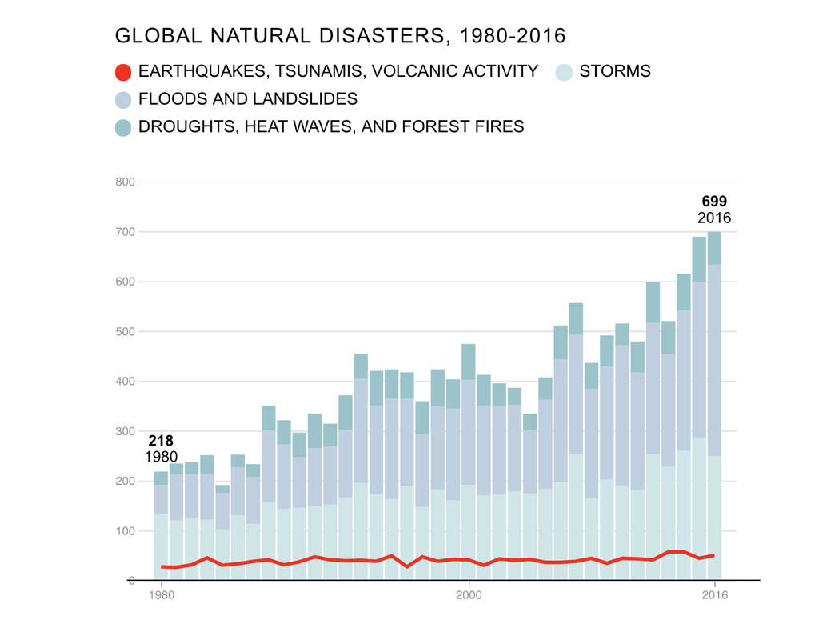

**Chart Evaluation**

[output not shown]

## 3.2 Atmospheric CO<sub>2</sub> concentration (ppm), 1700 - 2016, [Our World in Data](https://ourworldindata.org/co2-and-other-greenhouse-gas-emissions#impact-of-emissions-on-atmospheric-concentrations)

This chart shows global average long-term atmospheric concentration of carbon dioxide (CO₂), measured in parts per million (ppm).

Source for data: [Scripps CO<sub>2</sub> Program](http://scrippsco2.ucsd.edu/data/atmospheric_co2/icecore_merged_products)

[figure not shown]

**Chart Evaluation**

[output not shown]

## 3.3 Global temperature change, 1850 - 2017 by Ed Hawkins: [Climate Lab Book](https://www.climate-lab-book.ac.uk/spirals/)

The website states - *“The animated climate spiral below is a different way to show the historically observed changes in global temperature. The original version quickly went viral, and was seen millions of times on Facebook and Twitter. A version was even used in the opening ceremony of the Rio Olympics!”*

Source for data: [Met Office Hadley Centre observations datasets, HadCRUT4](https://www.metoffice.gov.uk/hadobs/hadcrut4/)

[figure not shown]

**Chart Evaluation**

[output not shown]